# HW_Glazkov

Nadezhda Tsurikova

2023-01-29

```r
library(readxl)
library(ROCR)
library(pROC)
library(tibble)
library(xtable)
library(gtsummary)
library(tidyverse)
library(tidyr)
library(purrr)
library(flextable)
```

```r
library(corrplot)
library(corrr)
```

```r
diab <- read_excel("C:/Users/Nadine/Downloads/diabetes.xlsx")

diab %>% glimpse()
```

```
## Rows: 768
## Columns: 9
## $ Pregnancies              <dbl> 6, 1, 8, 1, 0, 5, 3, 10, 2, 8, 4, 10, 10, 1, …
## $ Glucose                  <dbl> 148, 85, 183, 89, 137, 116, 78, 115, 197, 125…
## $ BloodPressure            <dbl> 72, 66, 64, 66, 40, 74, 50, 0, 70, 96, 92, 74…
## $ SkinThickness            <dbl> 35, 29, 0, 23, 35, 0, 32, 0, 45, 0, 0, 0, 0, …
## $ Insulin                  <dbl> 0, 0, 0, 94, 168, 0, 88, 0, 543, 0, 0, 0, 0, …
## $ BMI                      <chr> "33.6", "44738.0", "44643.0", "44589.0", "43.…
## $ DiabetesPedigreeFunction <chr> "0.627", "0.351", "0.672", "0.167", "2.288", …
## $ Age                      <dbl> 50, 31, 32, 21, 33, 30, 26, 29, 53, 54, 30, 3…
## $ Outcome                  <dbl> 1, 0, 1, 0, 1, 0, 1, 0, 1, 1, 0, 1, 0, 1, 1, …
```

```r
diab <- diab %>%
    mutate(across(c(Outcome), ~ as.factor(.x))) %>%
  mutate(across(c(BMI), ~ as.numeric(.x)))

diab %>% glimpse()
```

```
## Rows: 768
## Columns: 9
## $ Pregnancies              <dbl> 6, 1, 8, 1, 0, 5, 3, 10, 2, 8, 4, 10, 10, 1, …
## $ Glucose                  <dbl> 148, 85, 183, 89, 137, 116, 78, 115, 197, 125…
## $ BloodPressure            <dbl> 72, 66, 64, 66, 40, 74, 50, 0, 70, 96, 92, 74…
## $ SkinThickness            <dbl> 35, 29, 0, 23, 35, 0, 32, 0, 45, 0, 0, 0, 0, …
## $ Insulin                  <dbl> 0, 0, 0, 94, 168, 0, 88, 0, 543, 0, 0, 0, 0, …
## $ BMI                      <dbl> 33.6, 44738.0, 44643.0, 44589.0, 43.1, 44737.…
## $ DiabetesPedigreeFunction <chr> "0.627", "0.351", "0.672", "0.167", "2.288", …
## $ Age                      <dbl> 50, 31, 32, 21, 33, 30, 26, 29, 53, 54, 30, 3…
## $ Outcome                  <fct> 1, 0, 1, 0, 1, 0, 1, 0, 1, 1, 0, 1, 0, 1, 1, …
```

смотрим где есть нули

```r
colSums(diab==0)
```

```
##              Pregnancies                  Glucose            BloodPressure
##                      111                        5                       35
##            SkinThickness                  Insulin                      BMI
##                      227                      374                       11
## DiabetesPedigreeFunction                      Age                  Outcome
##                        0                        0                      500
```

заменяем нули на NA

```r
diab_no.na <- diab %>% mutate_at(c('Glucose', 'BloodPressure', 'SkinThickness', 'Insulin'), ~na_if(., 0))
```

#У какого количества пациентов из датасета присутствует нарушенная толерантность к глюкозе (НТГ)? Критерий НТГ – это уровень повышение гликемии ≥ 7.8 ммоль/л на 120 минуте теста на толерантность к глюкозе. Сколько в датасете пациентов, у которых нет НТГ?

```r
NTG <- diab_no.na$Glucose /18
as <- NTG >=7.8
sum(as, na.rm=T)
```

```
## [1] 192
```

#Сколько в датасете пациентов, у которых нет НТГ?

```r
length(NTG) - sum(as, na.rm=T)
```

```
## [1] 576
```

#Как выглядит ROC-кривая для предсказания сахарного диабета по переменной, характеризующей уровень гликемии? Постройте график.

```r
roc_curve_1 <- roc(Outcome ~ Glucose, data = diab_no.na, ci = T)
roc_curve_1
```

```
##
## Call:
## roc.formula(formula = Outcome ~ Glucose, data = diab_no.na, ci = T)
##
## Data: Glucose in 497 controls (Outcome 0) < 266 cases (Outcome 1).
## Area under the curve: 0.7928
## 95% CI: 0.7599-0.8257 (DeLong)
```

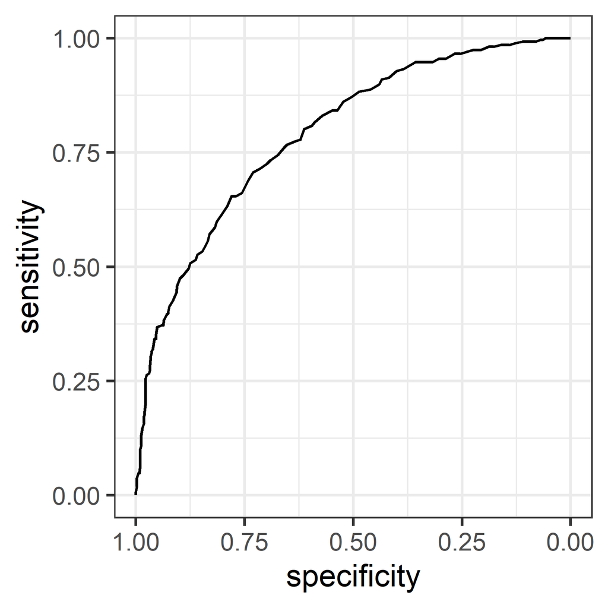

```r
ggroc(roc_curve_1) +
    theme_bw()
```

#Чему равна площадь под ROC-кривой, которую вы построили в вопросе 2

```r
auc(diab_no.na$Outcome, diab_no.na$Glucose)
```

```
## Area under the curve: 0.7928
```

Площадь составляет 0.7928

#Чему равен 95% двусторонний ДИ для площади под ROC-кривой, которую вы построили в вопросе 2

```r
ci.auc(diab_no.na$Outcome, diab_no.na$Glucose)
```

```
## 95% CI: 0.7599-0.8257 (DeLong)
```

выбираем лучший порог

```r
roc_curve_1 %>% coords(x = "best", best.method = "closest.topleft")
```

```
##   threshold specificity sensitivity
## 1     123.5   0.7303823   0.7067669
```

#Постройте ROC-кривую и определите, какое пороговое значение является оптимальным для предсказания сахарного диабета по уровню инсулина? Какой чувствительностью и специфичностью обладает данный порог?

```r
roc_curve_2 <- roc(Outcome ~ Insulin, data = diab_no.na, ci = T)
roc_curve_2
```

```
##
## Call:
## roc.formula(formula = Outcome ~ Insulin, data = diab_no.na, ci = T)
##
## Data: Insulin in 264 controls (Outcome 0) < 130 cases (Outcome 1).
## Area under the curve: 0.7316
## 95% CI: 0.6809-0.7824 (DeLong)
```

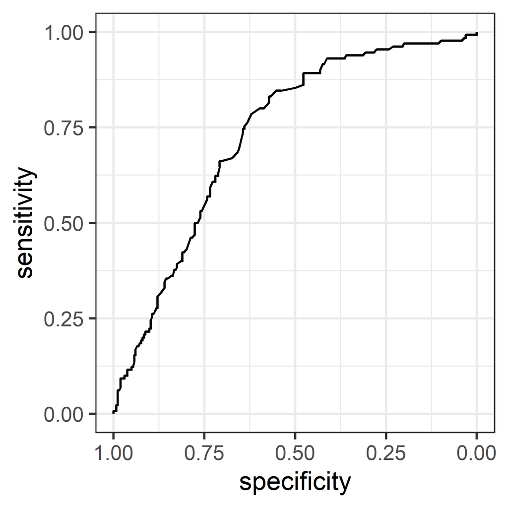

```r
ggroc(roc_curve_2) +
    theme_bw()
```

#Чему равна площадь под ROC-кривой, которую вы построили в вопросе 2

```r
auc(diab_no.na$Outcome, diab_no.na$Insulin)
```

```
## Area under the curve: 0.7316
```

Площадь равна 0.731

#Чему равен 95% двусторонний ДИ для площади под ROC-кривой, которую вы построили в вопросе 2

```r
ci.auc(diab_no.na$Outcome, diab_no.na$Insulin)
```

```
## 95% CI: 0.6809-0.7824 (DeLong)
```

выбираем лучший порог

```r
roc_curve_2 %>% coords(x = "best", best.method = "closest.topleft")
```

```
##   threshold specificity sensitivity
## 1       121   0.6212121   0.7846154
```

Лучший порог: чувствительность 0.784, специфичность 0.621

#число беременностей

```r
roc_curve_3 <- roc(Outcome ~ Pregnancies, data = diab_no.na, ci = T)
roc_curve_3
```

```
##
## Call:
## roc.formula(formula = Outcome ~ Pregnancies, data = diab_no.na,     ci = T)
##
## Data: Pregnancies in 500 controls (Outcome 0) < 268 cases (Outcome 1).
## Area under the curve: 0.6195
## 95% CI: 0.5764-0.6626 (DeLong)
```

```r
auc(diab$Outcome, diab$Pregnancies)
```

```
## Area under the curve: 0.6195
```

выбираем лучший порог

```r
roc_curve_3 %>% coords(x = "best", best.method = "closest.topleft")
```

```
##   threshold specificity sensitivity
## 1       3.5       0.622   0.5783582
```

АД

```r
roc_curve_4 <- roc(Outcome ~ BloodPressure, data = diab_no.na, ci = T)
roc_curve_4
```

```
##
## Call:
## roc.formula(formula = Outcome ~ BloodPressure, data = diab_no.na,     ci = T)
##
## Data: BloodPressure in 481 controls (Outcome 0) < 252 cases (Outcome 1).
## Area under the curve: 0.6076
## 95% CI: 0.5652-0.65 (DeLong)
```

```r
auc(diab$Outcome, diab$BloodPressure)
```

```
## Area under the curve: 0.5865
```

выбираем лучший порог

```r
roc_curve_4 %>% coords(x = "best", best.method = "closest.topleft")
```

```
##   threshold specificity sensitivity
## 1      75.5   0.6590437   0.4960317
```

толщина кожной складки на трицепсе

```r
roc_curve_5 <- roc(Outcome ~ SkinThickness, data = diab_no.na, ci = T)
roc_curve_5
```

```
##
## Call:
## roc.formula(formula = Outcome ~ SkinThickness, data = diab_no.na,     ci = T)
##
## Data: SkinThickness in 361 controls (Outcome 0) < 180 cases (Outcome 1).
## Area under the curve: 0.6625
## 95% CI: 0.6156-0.7094 (DeLong)
```

```r
auc(diab$Outcome, diab$SkinThickness)
```

```
## Area under the curve: 0.5536
```

выбираем лучший порог

```r
roc_curve_5 %>% coords(x = "best", best.method = "closest.topleft")
```

```
##   threshold specificity sensitivity
## 1      28.5   0.5623269   0.6888889
```

ИМТ

```r
roc_curve_7 <- roc(Outcome ~ BMI, data = diab_no.na, ci = T)
roc_curve_7
```

```
##
## Call:
## roc.formula(formula = Outcome ~ BMI, data = diab_no.na, ci = T)
##
## Data: BMI in 500 controls (Outcome 0) > 268 cases (Outcome 1).
## Area under the curve: 0.5757
## 95% CI: 0.5346-0.6168 (DeLong)
```

```r
auc(diab$Outcome, diab$BMI)
```

```
## Area under the curve: 0.5757
```

выбираем лучший порог

```r
roc_curve_7 %>% coords(x = "best", best.method = "closest.topleft")
```

```
##   threshold specificity sensitivity
## 1  22323.55       0.466   0.7723881
```

возраст

```r
roc_curve_8 <- roc(Outcome ~ Age, data = diab_no.na, ci = T)
roc_curve_8
```

```
##
## Call:
## roc.formula(formula = Outcome ~ Age, data = diab_no.na, ci = T)
##
## Data: Age in 500 controls (Outcome 0) < 268 cases (Outcome 1).
## Area under the curve: 0.6869
## 95% CI: 0.649-0.7249 (DeLong)
```

```r
auc(diab$Outcome, diab$Age)
```

```
## Area under the curve: 0.6869
```

выбираем лучший порог

```r
roc_curve_8 %>% coords(x = "best", best.method = "closest.topleft")
```

```
##   threshold specificity sensitivity
## 1      30.5       0.654   0.6641791
```

#Как вы можете интерпретировать это знание? Какая количественная переменная имеет наименьшую площадь? ##наибольшая площадь у колонки “глюкоза”, наименьшая - “толщина кожной складки”. Большая площадь рок-кривой говорит о высокой предсказательной модели данного графика, маленькая площадь - говорит о низкой предсказательной модели и на нее лучше не ориентироваться при проведении анализа.